# MyHomework10

## 工作空間

在 R 的互動式環境下工作時，我們可以使用 ls 來列出目前已經被建立的變數名稱：

```r
foo <- 3
bar <- "Hello World"
foo.bar <- 1:5
ls()
```

```
##  [1] "a"        "b"        "bar"      "c"        "foo"      "foo.bar"
##  [7] "gender"   "x"        "xy.df"    "y"        "y.factor"
```

ls 的 pattern 參數可以指定搜尋的關鍵字，篩選變數名稱：

```r
ls(pattern = "foo")
```

```
## [1] "foo"     "foo.bar"
```

ls.str 是結合 ls 與 str 的一個函數，可以列出各個變數的名稱與內部結構：

```r
ls.str()
```

```
## a :  num 1
## b :  num 2
## bar :  chr "Hello World"
## c :  num 3
## foo :  num 3
## foo.bar :  int [1:5] 1 2 3 4 5
## gender :  Factor w/ 2 levels "female","male": 2 1 2
## x :  num [1:30] 0.292 0.4906 -1.5803 -0.8266 -0.0799 ...
## xy.df : 'data.frame':    30 obs. of  2 variables:
##  $ x: num  0.292 0.4906 -1.5803 -0.8266 -0.0799 ...
##  $ y: Factor w/ 3 levels "A","B","C": 2 1 3 1 2 2 2 2 1 2 ...
## y :  chr [1:30] "B" "A" "C" "A" "B" "B" "B" "B" "A" "B" "B" "A" "A" "C" ...
## y.factor :  Factor w/ 3 levels "A","B","C": 2 1 3 1 2 2 2 2 1 2 ...
```

在瀏覽器中顯示目前工作空間中的變數：

```r
browseEnv()
```

```
## R objects in .GlobalEnv environment is shown in browser '/usr/bin/open'
```

如果要刪除一些不再使用的變數，可以使用 rm 函數：

```r
rm(bar, foo)
```

rm 可以配合 ls 將所有的變數一次刪除：

```r
rm(list = ls())
```

# Ｒ資料的輸入與輸出

## 資料輸入

```r
data()
data(iris)
head(iris)
```

```
##   Sepal.Length Sepal.Width Petal.Length Petal.Width Species
## 1          5.1         3.5          1.4         0.2  setosa
## 2          4.9         3.0          1.4         0.2  setosa
## 3          4.7         3.2          1.3         0.2  setosa
## 4          4.6         3.1          1.5         0.2  setosa
## 5          5.0         3.6          1.4         0.2  setosa
## 6          5.4         3.9          1.7         0.4  setosa
```

## 外部檔案輸入

```
read.csv("data.csv")
read.csv("data-tab-1.csv", sep = "\t")  #sep參數可指定分隔字元
```

2. 文字檔(txt)

```
scan("data-2.txt")  #資料直接變成一個向量
scan("data-4.txt", "")
```

## 資料檔案輸出

1. `sink`函數：讓程式的輸出訊息直接存到檔案

```r
sink("sink-example.txt")
i <- 1:3
outer(i, i, "*")
```

```
##      [,1] [,2] [,3]
## [1,]    1    2    3
## [2,]    2    4    6
## [3,]    3    6    9
```

```r
sink()
```

2. `save`函數：將變數儲存於硬碟中

```r
x <- c(1.2, 3.4, 5.6)
y <- x ^ 2
save(x, y, file = "xy.RData")
```

3. `load`函數：將儲存的變數載入

```r
rm(list = ls())
load("xy.RData")
ls.str()
```

```
## x :  num [1:3] 1.2 3.4 5.6
## y :  num [1:3] 1.44 11.56 31.36
```

## 圖形檔案輸出

1. `png`函數：將圖形輸出為 png 點陣圖檔

```r
set.seed(5)
x <- rnorm(100)
png("output.png", width = 640, height = 360) # 設定輸出圖檔
hist(x) # 繪圖
dev.off() # 關閉輸出圖檔
```

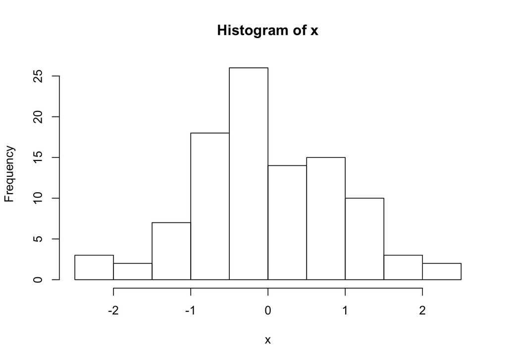

```r
hist(x)
```

2. `pdf`或`svg`函數：將圖形輸出為向量圖

```
pdf("output.pdf", width = 4, height = 3)
hist(x)
dev.off()
```

# Ｒ向量、矩陣與陣列

## 向量(Vectors)

在 R 中要建立向量最常使用的方式：

```r
c(1, 3, 5)  #使用c函數
```

```
## [1] 1 3 5
```

```r
1:5  #使用冒號(:)運算子
```

```
## [1] 1 2 3 4 5
```

```r
c(1:4, 8, 9, c(12, 23))  #合併，產生更長的新向量
```

```
## [1]  1  2  3  4  8  9 12 23
```

vector 函數可以用來建立特定類型與長度的向量：

```r
vector("numeric", 3)
```

```
## [1] 0 0 0
```

```r
vector("logical", 3)
```

```
## [1] FALSE FALSE FALSE
```

```r
vector("character", 3)
```

```
## [1] "" "" ""
```

```r
vector("list", 3)
```

[output not shown]

使用 vector 所建立的向量，其內部的值都是 0、FALSE 或 NULL 這類的空值。

對於一些常用的變數類型，R 提供了比較簡潔的函數方便使用者呼叫：

```r
numeric(3)
```

```
## [1] 0 0 0
```

```r
logical(3)
```

```
## [1] FALSE FALSE FALSE
```

```r
character(3)
```

```
## [1] "" "" ""
```

## 序列（Sequences）

冒號運算子可以讓我們快速建立簡單的向量，如果需要產生較複雜的向量，在 R 中有一系列的相關函數可以使用。

1. `seq`函數：可產生各種序列

```r
seq(2, 5)  #等同於 2:5
```

```
## [1] 2 3 4 5
```

```r
seq(2, 5, by = 0.5)  #間隔長
```

```
## [1] 2.0 2.5 3.0 3.5 4.0 4.5 5.0
```

```r
seq(from = 2, to = 5, by = 0.5)  #與上式同
```

```
## [1] 2.0 2.5 3.0 3.5 4.0 4.5 5.0
```

```r
seq(2, 5, length = 5)  #分為五個
```

```
## [1] 2.00 2.75 3.50 4.25 5.00
```

2. `seq.int`函數：亦以產生一般的數值序列，但其執行效率較高

```r
seq.int(2, 5)
```

```
## [1] 2 3 4 5
```

```r
seq.int(2, 5, by = 0.5)
```

```
## [1] 2.0 2.5 3.0 3.5 4.0 4.5 5.0
```

```r
seq.int(2, 5, length = 5)
```

```
## [1] 2.00 2.75 3.50 4.25 5.00
```

### 向量長度

所有的向量都有一個長度屬性，記錄該向量所含有的元素數量，我們可以使用 length 函數來檢查向量的長度：

```r
length(1:3)
```

```
## [1] 3
```

```r
length(c(TRUE, FALSE, NA))
```

```
## [1] 3
```

```r
str <- c("hello", "foo", "bar")
length(str)  #向量的長度
```

```
## [1] 3
```

```r
nchar(str)  #字串的長度
```

```
## [1] 5 3 3
```

### 向量元素名稱

R 的向量有一個很特別的地方就是每一個元素都可以有一個自己的名稱，替向量的元素標上個別的名稱可以讓程式碼更容易被閱讀。

1. 在建立向量時，我們可以使用 name = value 的方式指定元素的名稱：

```r
c(foo = 2, bar = 4)
```

```
## foo bar
##   2   4
```

```r
c(foo = 2, bar = 4, "hello world" = 6, 8)
```

```
##         foo         bar hello world
##           2           4           6           8
```

2. 一般的向量可以使用 `names` 函數來指定向量的名稱：

```r
x <- 1:4
names(x) <- c("foo", "bar", "hello world", "")
x
```

```
##         foo         bar hello world
##           1           2           3           4
```

```r
names(x)  #取得向量元素的名稱
```

```
## [1] "foo"         "bar"         "hello world" ""
```

3. `which`函數可以檢查邏輯向量，傳回該向量中所有 TRUE 元素的位置：

```r
x <- 10:20
which(x %% 7 == 3)  #找出x向量中所有除以7餘數為3的元素位置
```

```
## [1] 1 8
```

另外，which.min 與 which.max 分別等同於 which(min(x)) 與 which(max(x))，不過執行效率更好：

```r
which.min(x)
```

```
## [1] 1
```

```r
which.max(x)
```

```
## [1] 11
```

### 重複向量

在處理向量的運算時，如果遇到長度不同的向量，R 就會將長度較短的向量自動重複，直到其長度跟最長的向量相同為止：

```r
1:3 + 1:9
```

```
## [1]  2  4  6  5  7  9  8 10 12
```

```r
1:5 + 1  #向量與常數相加時也是
```

```
## [1] 2 3 4 5 6
```

```r
1:2 + 1:5  #常讀不是倍數時，以此為例，`1:2`會重複2.5次＝c(1, 2, 1, 2, 1)
```

```
## [1] 2 4 4 6 6
```

若要產生重複性的向量，可以使用 rep 這個函數，其第一個參數是要重複的向量，而第二個參數則是重複次數：

```r
rep(1:4, 3)
```

```
##  [1] 1 2 3 4 1 2 3 4 1 2 3 4
```

```r
rep(1:4, each = 3)  #各別重複後再串起來
```

```
##  [1] 1 1 1 2 2 2 3 3 3 4 4 4
```

```r
rep(1:4, 4:1)  #讓每一個元素重複不同的次數
```

```
##  [1] 1 1 1 1 2 2 2 3 3 4
```

```r
rep(1:4, length.out = 7)  #指定輸出的向量長度
```

```
## [1] 1 2 3 4 1 2 3
```

```r
rep.int(1:4, 3)  #執行效率更高
```

```
##  [1] 1 2 3 4 1 2 3 4 1 2 3 4
```

```r
rep_len(1:4, 7)  #執行效率也很高
```

```
## [1] 1 2 3 4 1 2 3
```

## 矩陣與陣列(matrices and arrays)

### 建立矩陣和陣列

R 的矩陣可以使用 `matrix` 函數建立：

```r
matrix(1:6, nrow = 2, ncol = 3)
```

```
##      [,1] [,2] [,3]
## [1,]    1    3    5
## [2,]    2    4    6
```

```r
matrix(1:6, nrow = 2, ncol = 3, byrow = TRUE)  #byrow 參數可調整資料排列的方向
```

```
##      [,1] [,2] [,3]
## [1,]    1    2    3
## [2,]    4    5    6
```

```r
matrix(1:6, nrow = 2, ncol = 3,
  dimnames = list(c("row1", "row2"),
  c("C.1", "C.2", "C.3")))  #行與列可使用dimnames 參數指定名稱
```

```
##      C.1 C.2 C.3
## row1   1   3   5
## row2   2   4   6
```

多維度的陣列則是使用 `array` 函數來建立：

```r
array(1:24, dim = c(4, 3, 2))
```

```
## , , 1
##
##      [,1] [,2] [,3]
## [1,]    1    5    9
## [2,]    2    6   10
## [3,]    3    7   11
## [4,]    4    8   12
##
## , , 2
##
##      [,1] [,2] [,3]
## [1,]   13   17   21
## [2,]   14   18   22
## [3,]   15   19   23
## [4,]   16   20   24
```

```r
array(1:24, dim = c(4, 3, 2), dimnames = list(
  X = c("A1","A2","A3","A4"),
  Y = c("B1", "B2", "B3"), Z = c("C1", "C2"))) #每個維度皆可使用 dimnames 參數指定名稱
```

```
## , , Z = C1
##
##     Y
## X    B1 B2 B3
##   A1  1  5  9
##   A2  2  6 10
##   A3  3  7 11
##   A4  4  8 12
##
## , , Z = C2
##
##     Y
## X    B1 B2 B3
##   A1 13 17 21
##   A2 14 18 22
##   A3 15 19 23
##   A4 16 20 24
```

也就是說，二維的陣列就是矩陣，不管使用 matrix 或是 array 來產生，結果都是一樣的：

```r
x.matrix <- matrix(1:6, nrow = 2, ncol = 3)
x.array <- array(1:6, dim = c(2, 3))
identical(x.matrix, x.array)
```

```
## [1] TRUE
```

```r
class(x.array)  #檢查 x.array 的類型
```

```
## [1] "matrix"
```

```r
nrow(x.matrix)  #檢查矩陣的列數
```

```
## [1] 2
```

```r
ncol(x.matrix)  #檢查矩陣的行數
```

```
## [1] 3
```

nrow 與 ncol 函數若用於多維度的陣列，會傳回前兩個維度的長度。

```r
x.array <- array(1:60, dim = c(3, 4, 5))
nrow(x.array)
```

```
## [1] 3
```

```r
ncol(x.array)
```

```
## [1] 4
```

length 函數也可以用於矩陣或是陣列，他會計算矩陣或陣列中所有元素的個數（也就是所有維度長度的乘積）：

```r
length(x.matrix)
```

```
## [1] 6
```

```r
length(x.array)
```

```
## [1] 60
```

若要改變矩陣或陣列的維度，可以使用 dim 指定新的維度：

```r
x.matrix <- matrix(1:12, nrow = 4, ncol = 3)
dim(x.matrix) <- c(2, 6)
x.matrix
```

```
##      [,1] [,2] [,3] [,4] [,5] [,6]
## [1,]    1    3    5    7    9   11
## [2,]    2    4    6    8   10   12
```

甚至可以透過改變維度，將二維矩陣轉換為高維度的陣列：

```r
dim(x.matrix) <- c(2, 3, 2)
x.matrix
```

```
## , , 1
##
##      [,1] [,2] [,3]
## [1,]    1    3    5
## [2,]    2    4    6
##
## , , 2
##
##      [,1] [,2] [,3]
## [1,]    7    9   11
## [2,]    8   10   12
```

nrow、ncol 與 dim 這幾個函數如果用在一維的向量時，會傳回 NULL，可以改用 NROW 與 NCOL 函數，這兩個函數的作用跟 nrow 與 ncol 相同：

```r
x.vector <- 1:5
nrow(x.vector)
```

[output not shown]

```r
NROW(x.vector)
```

```
## [1] 5
```

```r
ncol(x.vector)
```

[output not shown]

```r
NCOL(x.vector)
```

```
## [1] 1
```